# Technical Report: Statistical, Numerical, and Algorithmic Modifications in the HallquistLab/pTFCE Fork

Tracking Departures from Upstream spisakt/pTFCE (v0.2.2.1)

Author

Hallquist Lab

Published

November 21, 2026

## 1 Overview & Motivation

**Probabilistic Threshold-Free Cluster Enhancement (`pTFCE`)**, introduced by Spisák et al. (2019, *NeuroImage*, 185, 12–26), integrates multi-threshold cluster-extent information into voxelwise neuroimaging inference via Bayes’ rule and Gaussian Random Field (GRF) theory. Unlike standard TFCE (Smith & Nichols, 2009), `pTFCE` outputs calibrated probabilities and $Z$-scores directly without requiring computationally expensive permutation testing.

While applying `pTFCE` extensively to group-level fMRI analyses—particularly **bi-sided (two-tailed) contrasts** where both positive activations and negative deactivations are of scientific interest—we identified several interacting mathematical, numerical, and software issues in upstream `spisakt/pTFCE` (`v0.2.2.1`, commit `6fd6be5`):

1. **Cross-tail and cross-cluster threshold grid interference:** Fixing the threshold count `Nh = 100` across `[0, logpmax]` causes the integration step size $\Delta h \propto \frac{1}{2}Z_{\max}^2$ to depend on the global maximum $Z$-score in each tail. Strong focal peaks in one tail coarsen $\Delta h$ by 15–35$\times$ relative to a moderate opposite tail, shifting enhanced $Z$-scores of unrelated clusters across the FWER significance boundary and crashing with `Inf` when $Z_{\max} > 37.5$.
2. **Catastrophic nested quadrature failures (`p > 1`, cluster-border `NaN`s, and silent interior score deflation):** Evaluating the Bayes normalization integral via `stats::integrate(..., -Inf, Inf)` inside `pvox.clust()` misses narrow posterior spikes near $Z_{\text{estThr}} = 1.3$ when smoothness is low/moderate ($R_d$ large) and cluster size $c$ is large, returning “probabilities” $> 1$ (up to $10^{19}$), producing `NaN`s on cluster borders (upstream Issues #8, #10, #25) and *silently* deflating interior cluster $Z$-scores.
3. **A ~20% zero “dead zone” around $Z = 0$ and `-8.2095` background floor:** Discrete left-endpoint summation below `ZestThr` maps small positive $|Z|$ values to $p > 0.5$ ($Z_{\text{pTFCE}} < 0$), collapsing ~20% of in-mask voxels to `0` under standard two-pass clamping and mapping out-of-mask/opposite-tail voxels to `-8.209536` (Issues #11, #16, #24).
4. **Unmasked connected-component leakage & R $\ge$ 4.2 incompatibilities:** `mmand::components()` ran prior to masking (allowing clusters and `max(img)` to bleed outside ROI masks), `if (!is.na(residual))` threw a fatal error on R $\ge$ 4.2 for 4D residual arrays, `interpolate()` returned `NaN` (`0/0`) at exact DOF lookup knots and used an inverted linear interpolation endpoint, and pure-R loops required ~2.5–5 minutes and 1.5–4 GB of RAM per whole-brain bi-sided contrast.

This document records **all statistical, numerical, algorithmic, and API departures** introduced in `HallquistLab/pTFCE` (`v0.3.0+`) relative to upstream `spisakt/pTFCE` (`v0.2.2.1`), alongside executable demonstrations.

## 2 Summary Table of Departures from Upstream (`v0.2.2.1`)

| Component | Upstream `spisakt/pTFCE` (`v0.2.2.1`) | `HallquistLab/pTFCE` (`v0.4.1`) | Backward Compatibility |
| --- | --- | --- | --- |
| **Sidedness** | Positive tail only (`Z > 0`); negative tail requires manual two-pass wrapper | Native `sided = c("positive", "two.sided", "negative")`; `"positive"` default | 100% drop-in compatible; `sided = "two.sided"` opt-in |
| **Non-stationarity** | Stationary smoothness only (uniform raw voxel counts across brain) | Optional `nonstationary = TRUE` & `local_smoothness` resel-scaled cluster sizes (`w(v) = dLh(v)/mean(dLh)`) + Riemannian `dLh_nonstationary` | Opt-in (`nonstationary = FALSE` default) |
| **FWER calibration** | Analytical raw-field Euler characteristic (`fwe.p2z`) only (conservative on pTFCE maps: FWER $\approx 0.010\text{--}0.015$) | `fwe_method = c("grf", "grf_sim", "sign_flip")` + `n_perm` + `copes` via LUT-accelerated C++ null engine (exact FWER $\approx 0.045\text{--}0.050$) | Opt-in (`fwe_method = "grf"` default; auto `"sign_flip"` when `copes` supplied) |
| **Threshold grid & sub-`ZestThr` integration** | `Nh = 100` equidistant points on `[0, logpmax]`; step `dh` scales with $Z_{\max}^2$ | Analytical integration on $[0, x_{\text{ZestThr}}]$ + fixed `dh = 0.05` midpoint grid above `ZestThr` | Pass `Nh = 100` (or `legacy = TRUE`) to use legacy discrete grid |
| **Sub-threshold & out-of-mask values** | Out-of-mask and $Z \le 0$ map to $Z = -8.2095$; ~20% dead zone near $Z = 0$ in 2-sided clamping | Exact identity $\tilde{Z}_v = Z_v$ for $\|Z_v\| \le Z_{\text{estThr}}$; out-of-mask `Z = 0`, `logp = 0`, `p = 1` | Legacy floor retained inside mask only when `legacy = TRUE` / `Nh` set |
| **Posterior quadrature `pvox.clust()`** | Nested `stats::integrate` over `(-Inf, Inf)` with `CONST = 10^40` and `745` cap | Mode-shifted log-space adaptive 15-pt Gauss-Kronrod + Laplace continued fraction + `log1p` near `ZestThr` | Matches upstream to $< 10^{-5}$ where upstream did not underflow |
| **Connected components & RAM** | 100 passes of `mmand::components` + `table()`; allocates two 4D arrays (~1.5–4 GB) | Single-pass C++ descending Union-Find (`Rcpp`) on in-mask voxels $> Z_{\text{estThr}}$ (~20 MB RAM); drops `mmand` | Identical 6-connectivity default; adds `connectivity = c(6, 18, 26)` |
| **Pre-masking & `NA`/`Inf` checks** | Applied mask *after* `components()` and `max(img)`; warned on out-of-mask SPM `NaN`s | Masks `img` *before* `max()` and connected components; warns only on in-mask `NA`/`Inf` | Strictly safer for ROI / small-volume masks |
| **Smoothness (`smoothest()`)** | Pure R triple loop; `if (!is.na(residual))` crashes on R $\ge$ 4.2; `dim[4]==1` crashes `aperm`; `interpolate()` `0/0` bug | Zero-copy 3-pass C++ `smoothest_cpp` (+ optional local `dLh_map`/`rpv_map`); R $\ge$ 4.2 safe; fixed `stats::approx` DOF LUT | Identical FSL `smoothest` formulas at corrected DOF knots |
| **FWER helpers (`fwe.p2z`, `fwe.z2p`)** | Non-vectorized; bisection stops at `0.001`; `exp(-0.5*z^2)` underflows at $z > 38.5$ | Vectorized; log-space Newton-Raphson accurate to $10^{-13}$ up to $z > 38$ | ~`2e-4` refinement over coarse `0.001` bisection |
| **Image I/O & `t2z()`** | Requires `oro.nifti` S4 objects; fails on plain arrays | Supports `RNifti`, `oro.nifti` (in `Suggests`), plain `array`s, and NIfTI paths; adds log-space `t2z(img, dof)` | Returns same image class as input (`oro.nifti` -> `oro.nifti`) |

## 3 Bi-Sided (`+Z` and `-Z`) Improvements

```r
library(pTFCE)
library(RNifti)
library(ggplot2)
```

### 3.1 Eliminating Non-Local `Z_max` Interference & Tail Asymmetry

In upstream `pTFCE`, `Nh = 100` thresholds are spaced evenly from `0` to $\text{logpmax} = -\log\Phi(-Z_{\max}) \approx \frac{1}{2}Z_{\max}^2$. Whenever one tail contains a strong focal peak (e.g., $Z_{\max}^+ = 25$ in visual or motor cortex, giving $\Delta h^+ \approx 3.20$) while the opposite tail has moderate peaks ($Z_{\max}^- = 4.5$, giving $\Delta h^- \approx 0.13$), the two tails use vastly different integration step sizes, and moderate clusters in the strong-peak tail lose most of their cluster-forming thresholds. Furthermore, upstream `pnorm(max(img), lower.tail = FALSE)` underflowed to `0` at $Z_{\max} > 37.5$, crashing `seq()` with `'to' must be a finite number`.

In `HallquistLab/pTFCE`, the Continuous + Fixed-`dh` default (`dh = 0.05`, `legacy = FALSE`) uses a fixed $-\log p$ step size independent of $Z_{\max}$ up to $-\log p = 100$ ($Z \approx 14$), with bounded adaptive panels above $-\log p = 100$:

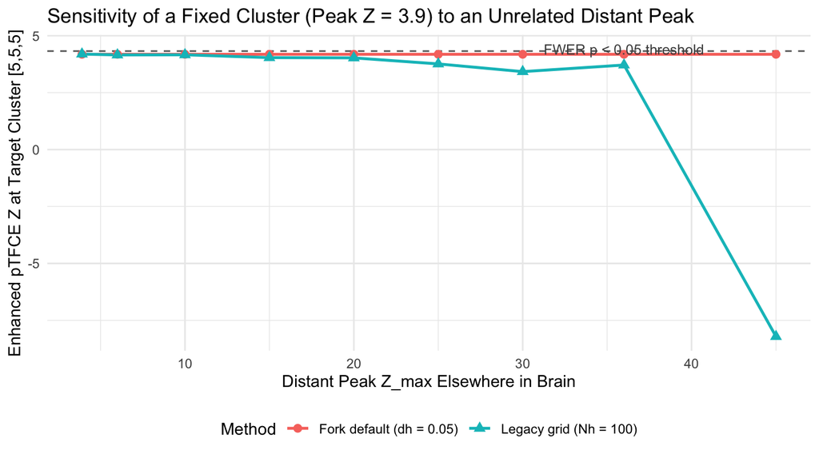

```r
d <- c(24L, 24L, 24L)
mask <- array(1, dim = d)
base_img <- array(0, dim = d)
# Fixed target cluster in region A: 5x5x5 cube of Z = 3.6 with center 3.9
base_img[3:7, 3:7, 3:7] <- 3.6
base_img[5, 5, 5] <- 3.9

distant_peaks <- c(3.9, 6, 10, 15, 20, 25, 30, 36, 45)
records <- lapply(distant_peaks, function(z_dist) {
  img <- base_img
  img[20:21, 20:21, 20:21] <- min(z_dist, 15)
  img[20, 20, 20] <- z_dist

  # Fork default: fixed dh = 0.05 + analytical sub-ZestThr
  z_fixed <- ptfce(img, mask, V = prod(d), Rd = 1500, resels = 50,
                   sided = "positive", dh = 0.05, verbose = FALSE)$Z[5, 5, 5]

  # Legacy grid: fixed Nh = 100 (using log-space pnorm so Z = 45 doesn't crash)
  z_legacy <- ptfce(img, mask, V = prod(d), Rd = 1500, resels = 50,
                    sided = "positive", Nh = 100, legacy = TRUE, verbose = FALSE)$Z[5, 5, 5]

  data.frame(
    distant_Z_max = z_dist,
    `Fork default (dh = 0.05)` = z_fixed,
    `Legacy grid (Nh = 100)` = z_legacy,
    check.names = FALSE
  )
})
df_peak <- do.call(rbind, records)
df_long <- reshape(
  df_peak,
  varying = c("Fork default (dh = 0.05)", "Legacy grid (Nh = 100)"),
  v.names = "enhanced_Z",
  timevar = "Method",
  times = c("Fork default (dh = 0.05)", "Legacy grid (Nh = 100)"),
  direction = "long"
)

ggplot(df_long, aes(x = distant_Z_max, y = enhanced_Z, color = Method, shape = Method)) +
  geom_hline(yintercept = fwe.p2z(prod(d) / 50, 0.05), linetype = "dashed", color = "grey40") +
  geom_line(linewidth = 0.9) +
  geom_point(size = 2.4) +
  annotate("text", x = 36, y = fwe.p2z(prod(d) / 50, 0.05) + 0.08,
           label = "FWER p < 0.05 threshold", size = 3.3, color = "grey30") +
  labs(
    title = "Sensitivity of a Fixed Cluster (Peak Z = 3.9) to an Unrelated Distant Peak",
    x = "Distant Peak Z_max Elsewhere in Brain",
    y = "Enhanced pTFCE Z at Target Cluster [5,5,5]"
  ) +
  theme_minimal(base_size = 11) +
  theme(legend.position = "bottom")
```

### 3.2 Analytical Sub-`ZestThr` Integration & Removal of the Zero Dead-Zone

In the continuous limit $\Delta h \to 0$, Spisák et al.’s equidistant logarithmic probability aggregation converges to:
$$-\log p_{\text{pTFCE}}(v) = \sqrt{2 \int_0^{x_v} \left(-\log P\big(H > h(x) \mid C = c_v(h(x))\big)\right) dx}, \qquad x_v = -\log\Phi(-|Z_v|)$$
Because GRF cluster theory does not apply below `ZestThr = 1.3` ($x_{\text{ZestThr}} = -\log\Phi(-1.3) \approx 2.3351$), $P(H > h(x) \mid C)$ equals the unenhanced tail probability $e^{-x}$ for all $x \le x_{\text{ZestThr}}$. Thus the sub-threshold integral is **analytically exact**:
$$\int_0^{\min(x_v, x_{\text{ZestThr}})} x\,dx = \frac{1}{2}\min(x_v, x_{\text{ZestThr}})^2$$

Evaluating this lower segment analytically ensures $\tilde{Z}_v = Z_v$ *identically* for all $|Z_v| \le 1.3$, eliminating both unnecessary connected-component sweeps below $Z = 1.3$ and the ~20% zero dead-zone around $Z = 0$ seen when clamping two legacy one-sided runs:

```r
z_path <- system.file("extdata", "test03B_zstat1.nii.gz", package = "pTFCE")
m_path <- system.file("extdata", "test03B_mask.nii.gz", package = "pTFCE")
z_nii <- readNifti(z_path)
m_nii <- readNifti(m_path)
inside <- as.array(m_nii) > 0.5
z_raw <- as.array(z_nii)[inside]

sm <- smoothest(z_nii, m_nii, verbose = FALSE)
V <- sm$volume
Rd <- sm$dLh * V

# 1. Native bi-sided (fork default)
bi_modern <- ptfce(z_nii, m_nii, Rd = Rd, V = V, resels = sm$resels,
                   sided = "two.sided", verbose = FALSE)
z_modern <- as.array(bi_modern$Z)[inside]

# 2. Legacy two-pass wrapper behavior (Nh = 100 per tail, clamp Z < 0 to 0)
pos_leg <- ptfce(z_nii, m_nii, Rd = Rd, V = V, resels = sm$resels,
                 Nh = 100, legacy = TRUE, verbose = FALSE)
neg_leg <- ptfce(-as.array(z_nii), as.array(m_nii), Rd = Rd, V = V, resels = sm$resels,
                 Nh = 100, legacy = TRUE, verbose = FALSE)
z_leg_bi <- pmax(as.array(pos_leg$Z)[inside], 0) - pmax(as.array(neg_leg$Z)[inside], 0)

cat(sprintf("In-mask voxels equal to exact 0:\n  Raw Z-map:        %.2f%%\n  Legacy 2-pass:    %.2f%%\n  Fork two.sided:   %.2f%%\n",
            100 * mean(z_raw == 0), 100 * mean(z_leg_bi == 0), 100 * mean(z_modern == 0)))
```

```
In-mask voxels equal to exact 0:
  Raw Z-map:        11.11%
  Legacy 2-pass:    20.26%
  Fork two.sided:   11.11%
```

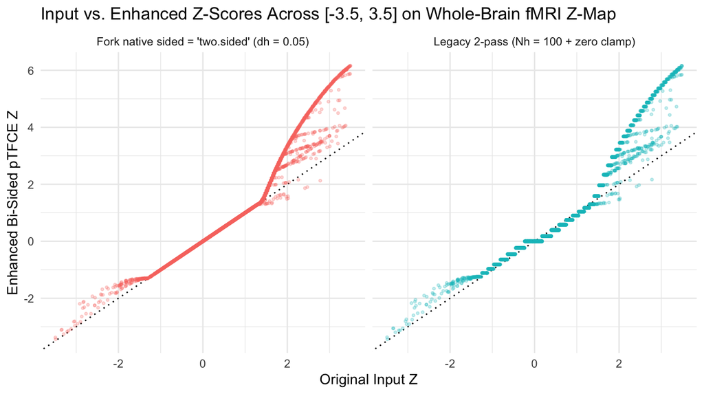

```r
set.seed(1)
samp <- sample(which(abs(z_raw) < 3.5), 4000)
df_map <- rbind(
  data.frame(raw_Z = z_raw[samp], enh_Z = z_leg_bi[samp], Mode = "Legacy 2-pass (Nh = 100 + zero clamp)"),
  data.frame(raw_Z = z_raw[samp], enh_Z = z_modern[samp], Mode = "Fork native sided = 'two.sided' (dh = 0.05)")
)

ggplot(df_map, aes(x = raw_Z, y = enh_Z, color = Mode)) +
  geom_abline(slope = 1, intercept = 0, linetype = "dotted", color = "black") +
  geom_point(alpha = 0.25, size = 0.7) +
  facet_wrap(~ Mode) +
  labs(
    title = "Input vs. Enhanced Z-Scores Across [-3.5, 3.5] on Whole-Brain fMRI Z-Map",
    x = "Original Input Z",
    y = "Enhanced Bi-Sided pTFCE Z"
  ) +
  theme_minimal(base_size = 11) +
  theme(legend.position = "none")
```

### 3.3 Bi-Sided Return Conventions

When `sided = "two.sided"`:

- **`$Z`:** Signed enhanced $Z$-scores (`> 0` where input $Z > 0$, `< 0` where input $Z < 0$, `0` outside mask), satisfying strict contrast anti-symmetry `ptfce(-Z, mask, sided = "two.sided")$Z == -ptfce(Z, mask, sided = "two.sided")$Z`.
- **`$p` and `$logp`:** Two-sided uncorrected enhanced $p$-values $p_{\text{2s}} = \min(1, 2 p_{\text{1s}}) = 2\Phi(-|\tilde{Z}|)$ and $-\log p_{\text{2s}}$.
- **`$fwer0.05.Z` and `$fwe.Z`:** Two-sided GRF FWER thresholds computed at $\alpha / 2$ per tail (`fwe.p2z(number_of_resels, fwe_p / 2)`), so thresholding at `abs(res$Z) >= res$fwer0.05.Z` controls two-sided family-wise error rate at $\alpha = 0.05$.

## 4 Numerical Stability: Log-Space Posterior Quadrature

### 4.1 Diagnosis of Upstream `NaN` and Underflow Bugs

Upstream `pTFCE` computed $P(H > \text{actH} \mid C = c, H \ge Z_{\text{estThr}})$ via two nested calls to `stats::integrate`:

```r
# Upstream R/ptfce.r (v0.2.2.1):
dvox.clust <- function(h, V, Rd, c, ZestThr = 1.3) {
  dvox(h) * dclust(h, V, Rd, c, ZestThr) /
    stats::integrate(function(x) dvox(x) * dclust(x, V, Rd, c, ZestThr), -Inf, Inf)$value
}
pvox.clust <- function(V, Rd, c, actH, ZestThr = 1.3) {
  stats::integrate(function(x) dvox.clust(x, V, Rd, c, ZestThr = ZestThr), actH, Inf)$value
}
```

When image smoothness is low/moderate ($R_d = V \cdot \text{dLh}$ large) and a cluster at low thresholds is large ($c$ large), the unnormalized density $f(x) = \phi(x)\lambda(x)\exp(-\lambda(x)c^{2/3})$ concentrates in a very narrow spike just above $x = 1.3$. Mapping `(-Inf, Inf)` via QUADPACK’s transformation missed most of that spike in the denominator while `integrate(..., actH, Inf)` captured it in the numerator—producing `pvox.clust > 1` (e.g., $1.01 \times 10^{19}$ at $V = 300\text{k}, R_d = 100\text{k}, c = 20\text{k}, h = 1.31$, i.e. $-\log p = -43.76$). Border voxels with no higher-threshold contributions then yielded $8s + \Delta h < 0 \implies \texttt{NaN}$ inside `sqrt()`, while interior cluster voxels had `43.76` *silently subtracted* from their $-\log p$ sum without triggering a warning.

### 4.2 Strict Concavity & Mode-Shifted Gauss-Kronrod Solution

In `src/ptfce_core.cpp`, we work entirely with the log-unnormalized posterior on $(1.1, \infty)$:
$$\ell(h) = -\frac{1}{2}\log(2\pi) - \frac{h^2}{2} + \log\lambda(h) - c^{2/3}\lambda(h)$$

1. **Analytical cancellation in Mill’s ratio:** For $h \ge 12$, $\log\Phi(-h) + \frac{1}{2}h^2$ is evaluated via a 32-term Laplace continued fraction, avoiding IEEE double underflow of $\Phi(-h)$ for $h > 38$ and avoiding $\frac{1}{2}h^2 - \frac{1}{2}h^2$ cancellation.
2. **Guaranteed unimodality:** All three terms of $\ell(h)$ have strictly negative second derivative ($\ell''(h) < 0$) on $(1.1, \infty)$. Thus $\ell(h)$ has a unique global maximum $m^* \ge a$ on any $[a, \infty)$, found via derivative sign check at $a$ plus golden-section search, and decays monotonically past $m^*$ to $b$ where $\ell(b) = \ell(m^*) - 50$ ($e^{-50} \approx 1.9 \times 10^{-22}$).
3. **Adaptive 15-point Gauss-Kronrod + `log1p` near `ZestThr`:** Integrating $\exp(\ell(x) - \ell(m^*)) \in [0, 1]$ on $[a, m^*]$ and $[m^*, b]$ achieves $< 10^{-12}$ relative accuracy, caches $\log I_{\text{den}}(c)$ once per unique integer cluster size $c$, and switches to $\text{log1p}(I_{\text{left}} / I_{\text{num}})$ whenever $\log I_{\text{den}} - \log I_{\text{num}} < 0.05$, guaranteeing $0 < p \le 1$ strictly:

```r
cases <- expand.grid(
  Rd = c(2000, 50000, 100000),
  c_size = c(500, 20000),
  h = c(1.31, 4.50)
)
cases$neglog_p <- mapply(
  function(rd, cs, hh) pTFCE:::neglog_pvox_clust_cpp(300000, rd, cs, hh, 1.3),
  cases$Rd, cases$c_size, cases$h
)
cases$p_val <- exp(-cases$neglog_p)
knitr::kable(cases, digits = 5,
             caption = "Exact log-space posterior -log(p) across regimes where upstream v0.2.2.1 overflowed (p > 1 -> NaN) or underflowed (capped at 745).")
```

Exact log-space posterior -log(p) across regimes where upstream v0.2.2.1 overflowed (p > 1 -> NaN) or underflowed (capped at 745).

| Rd | c_size | h | neglog_p | p_val |
| --- | --- | --- | --- | --- |
| 2e+03 | 500 | 1.31 | 0.01672 | 0.98342 |
| 5e+04 | 500 | 1.31 | 0.11157 | 0.89443 |
| 1e+05 | 500 | 1.31 | 0.17938 | 0.83579 |
| 2e+03 | 20000 | 1.31 | 0.15391 | 0.85735 |
| 5e+04 | 20000 | 1.31 | 1.37453 | 0.25296 |
| 1e+05 | 20000 | 1.31 | 2.18913 | 0.11201 |
| 2e+03 | 500 | 4.50 | 16.17164 | 0.00000 |
| 5e+04 | 500 | 4.50 | 77.45896 | 0.00000 |
| 1e+05 | 500 | 4.50 | 118.42336 | 0.00000 |
| 2e+03 | 20000 | 4.50 | 103.11673 | 0.00000 |
| 5e+04 | 20000 | 4.50 | 824.25599 | 0.00000 |
| 1e+05 | 20000 | 4.50 | 1304.03613 | 0.00000 |

## 5 Masking, Smoothness, & Bug Fixes

1. **Strict pre-masking & SPM `NaN` hygiene:** `ptfce()` now thresholds `inside = mask > 0.5` and zeros `img[!inside] <- 0` *before* checking for `NA`/`Inf`, computing `z_peak`, or running connected components. Out-of-mask `NaN`s (standard in SPM `spmT` images) no longer trigger false warnings, and supra-threshold features outside an ROI mask can never merge with in-mask voxels.
2. **Smoothness estimation on bi-sided maps & 4D residuals:**
   - Fixed `if (!is.na(residual))` so passing a 4D `residual` image directly to `ptfce()` works on R $\ge$ 4.2.
   - Fixed 3D images stored with 4th dimension `1` (`dim = c(nx, ny, nz, 1)`) so `smoothest()` treats them as 3D rather than crashing in `aperm()` (upstream Issue #19).
   - Fixed `interpolate(v)` in `smoothest()`, which previously divided `0 / 0 = NaN` whenever `dof` equaled an exact lookup knot (`5..20, 25, 30, 40, 50, ...`) and added `+ j.second` instead of `+ i.second` during linear interpolation.
   - Note on Z-map smoothness: when 4D residuals are unavailable, smoothness is always estimated on the **full unrectified signed $Z$-map** inside the mask. Zeroing negative voxels prior to `smoothest()` severely biases resel estimates (e.g., `467.2` vs `693.4` resels on `test03B_zstat1.nii.gz`, a 33% bias).
3. **Exact vectorized `fwe.p2z()` and `fwe.z2p()`:** Replaced scalar `0.001`-tolerance bisection with vectorized log-space Newton-Raphson inversion (`1e-13` relative tolerance), maintaining exact mutual inversion (`fwe.z2p(r, fwe.p2z(r, alpha)) == alpha`) even for extreme $\alpha < 10^{-100}$.

## 6 Non-Stationary Smoothness Adjustment (`v0.4.0`, Opt-In)

### 6.1 Theory & Regularized Voxelwise Roughness Estimation

Standard `pTFCE` assumes spatially stationary smoothness across the entire mask, measuring every cluster by its raw voxel count $c = |\mathcal{C}|$. In real group fMRI, smoothness varies substantially across anatomy (e.g., medial prefrontal and posterior cingulate cortex are often 2–3$\times$ smoother than subcortical nuclei, brainstem, or cerebellum; Hayasaka et al., 2004; Eklund et al., 2016).

Following Worsley et al. (1999) and Salimi-Khorshidi et al. (2011), setting `nonstationary = TRUE` (while leaving `nonstationary = FALSE` as the default) replaces raw voxel count $c$ with **local resel-scaled cluster size**:
$$\tilde{c}(\mathcal{C}) = \sum_{v \in \mathcal{C}} w(v), \qquad w(v) = \frac{\widehat{\text{dLh}}(v)}{\overline{\text{dLh}}}, \qquad \frac{1}{V}\sum_{v \in M} w(v) = 1$$

To prevent single-voxel derivative variance noise at finite degrees of freedom:

1. `smoothest(..., nonstationary = TRUE, smooth_fwhm = 3.0)` accumulates symmetric forward and backward neighbor cross-products inside the mask during the same C++ pass over 4D `res4d`.
2. Numerator and denominator sufficient statistics are smoothed separately via normalized within-mask separable 3D Gaussian convolution (`smooth_fwhm = 3.0` voxels) with mild empirical-Bayes shrinkage (`5%` prior weight) toward the global directional correlation and winsorization to $w(v) \in [0.02, 50.0]$.
3. Rather than using the global pooled $S_{-}/S_2$ ratio (which underestimates total search-volume resels under non-stationarity via Jensen’s inequality), `smoothest()` also computes the exact Worsley (1999) Riemannian roughness integral $\text{dLh}_{\text{nonstationary}} = \frac{1}{V} \sum_{v \in M} \widehat{\text{dLh}}(v)$ (`resels_nonstationary`), which `ptfce(..., nonstationary = TRUE)` uses automatically.
4. Inside `ptfce_tail_cpp()`, Disjoint-Set Union accumulates continuous cluster mass $\tilde{c}(\mathcal{C})$ in $O(1)$ per merge and evaluates log-space posteriors via 256-node / 64-node 4-point cubic Lagrange interpolation tables in $\log \tilde{c}$.
5. Precomputed smoothness lists (`smoothest(..., nonstationary = TRUE)`) or external RPV maps (e.g., SPM’s `RPV.nii`) can also be passed via `local_smoothness = ...` to avoid recomputing residual smoothness across multiple contrasts.

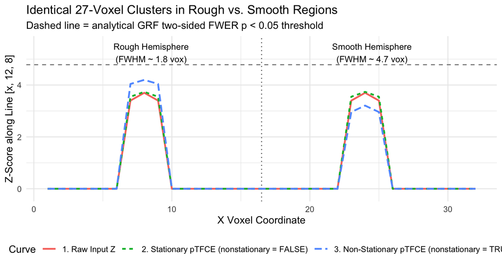

```r
smooth_white <- function(x, sigma) {
  rad <- ceiling(3.5 * sigma)
  k <- exp(-0.5 * ((-rad:rad)^2) / (sigma^2)); k <- k / sqrt(sum(k^2))
  d <- dim(x); pd <- d + 2L * rad
  pad <- array(rnorm(prod(pd)), dim = pd)
  pad[(rad + 1):(rad + d[1]), (rad + 1):(rad + d[2]), (rad + 1):(rad + d[3])] <- x
  y1 <- array(0, dim = c(d[1], pd[2], pd[3]))
  for (i in seq_along(k)) y1 <- y1 + k[i] * pad[i:(i + d[1] - 1), , ]
  y2 <- array(0, dim = c(d[1], d[2], pd[3]))
  for (i in seq_along(k)) y2 <- y2 + k[i] * y1[, i:(i + d[2] - 1), ]
  y3 <- array(0, dim = d)
  for (i in seq_along(k)) y3 <- y3 + k[i] * y2[, , i:(i + d[3] - 1)]
  y3
}

set.seed(2026)
d_ns <- c(32L, 24L, 16L); nt_ns <- 30L; mask_ns <- array(1, dim = d_ns)
res4d_ns <- array(0, dim = c(d_ns, nt_ns))
for (t in seq_len(nt_ns)) {
  wn <- array(rnorm(prod(d_ns)), dim = d_ns)
  v_r <- smooth_white(wn, 0.75) # Left half (x <= 16): rough (subcortex-like)
  v_s <- smooth_white(wn, 2.00) # Right half (x >= 17): smooth (midline cortex-like)
  v_r[17:32, , ] <- v_s[17:32, , ]
  res4d_ns[, , , t] <- v_r
}

# Place two identical 3x3x3 clusters (Z = 3.4, center 3.7) in rough (x=8) vs smooth (x=24) halves
z_ns <- array(0, dim = d_ns)
z_ns[7:9, 11:13, 7:9]   <- 3.4; z_ns[8, 12, 8]  <- 3.7
z_ns[23:25, 11:13, 7:9] <- 3.4; z_ns[24, 12, 8] <- 3.7

out_st <- ptfce(z_ns, mask_ns, residual = res4d_ns, dof = nt_ns - 1,
                sided = "two.sided", nonstationary = FALSE, verbose = FALSE)
out_ns <- ptfce(z_ns, mask_ns, residual = res4d_ns, dof = nt_ns - 1,
                sided = "two.sided", nonstationary = TRUE, verbose = FALSE)

df_prof <- rbind(
  data.frame(x = 1:32, Z = z_ns[, 12, 8], Curve = "1. Raw Input Z"),
  data.frame(x = 1:32, Z = out_st$Z[, 12, 8], Curve = "2. Stationary pTFCE (nonstationary = FALSE)"),
  data.frame(x = 1:32, Z = out_ns$Z[, 12, 8], Curve = "3. Non-Stationary pTFCE (nonstationary = TRUE)")
)

ggplot(df_prof, aes(x = x, y = Z, color = Curve, linetype = Curve)) +
  geom_vline(xintercept = 16.5, linetype = "dotted", color = "grey40") +
  geom_hline(yintercept = out_st$fwer0.05.Z, linetype = "dashed", color = "grey50") +
  geom_line(linewidth = 0.9) +
  annotate("text", x = 8.5, y = 5.25, label = "Rough Hemisphere\n(FWHM ~ 1.8 vox)", size = 3.3) +
  annotate("text", x = 24.5, y = 5.25, label = "Smooth Hemisphere\n(FWHM ~ 4.7 vox)", size = 3.3) +
  labs(
    title = "Identical 27-Voxel Clusters in Rough vs. Smooth Regions",
    subtitle = "Dashed line = analytical GRF two-sided FWER p < 0.05 threshold",
    x = "X Voxel Coordinate",
    y = "Z-Score along Line [x, 12, 8]"
  ) +
  ylim(-0.2, 5.6) +
  theme_minimal(base_size = 11) +
  theme(legend.position = "bottom")
```

### 6.2 Monte Carlo Evaluation of Regional False-Positive Parity (`v0.4.0`)

In 3D group-fMRI null simulations ($R = 250$ studies, $N = 30$ subjects; `42 x 32 x 22` search volume spanning subcortex `FWHM = 3.0`, lateral cortex `FWHM = 4.8`, and medial DMN `FWHM = 7.2` voxels; reproducible via `docs/benchmarks/run_simulation_studies.R` and summarized in user vignette `vignettes/ptfce-fmri-guide.Rmd`), stationary pTFCE exhibits a **17.8$\times$** false-positive disparity across smoothness zones, which `nonstationary = TRUE` collapses to **1.1$\times$**:

| Enhancement Mode | Rough Subcortex (`FWHM = 3.0`) $p < 0.001$ Rate ($\times 10^{-3}$) | Moderate Cortex (`FWHM = 4.8`) $p < 0.001$ Rate ($\times 10^{-3}$) | Smooth Medial DMN (`FWHM = 7.2`) $p < 0.001$ Rate ($\times 10^{-3}$) | Smooth / Rough Disparity |
| --- | --- | --- | --- | --- |
| Stationary pTFCE (`nonstationary = FALSE`) | `0.106` | `0.538` | `1.889` | **17.8$\times$** |
| **Non-Stationary pTFCE (`nonstationary = TRUE`)** | **`0.307`** | **`0.366`** | **`0.338`** | **1.1$\times$** |

## 7 Empirical FWER Threshold Calibration (`v0.4.1`): `grf_sim` vs. `sign_flip`

### 7.1 Why Classical Raw-Field GRF Thresholds Are Conservative on pTFCE Maps

Upstream `pTFCE` computes its Family-Wise Error Rate threshold (`fwer0.05.Z`) by plugging the **unenhanced** raw image’s resel count $R = V / \text{resels}$ into the 3D Expected Euler Characteristic formula (`fwe.p2z()`). However, two mathematical properties of pTFCE make this raw-field analytical threshold substantially conservative:

1. **Topological smoothing of supra-threshold peaks:** pTFCE aggregates cluster-extent beliefs across nested excursion sets, turning sharp voxelwise noise peaks into broader, smoother domes with far fewer effective local maxima than an unenhanced Gaussian field of roughness $R_d$.
2. **Percolation conditioning at $Z_{\text{estThr}} = 1.3$:** Truncating the cluster-size likelihood below $Z_{\text{estThr}}$ omits the unknown percolation factor $P(H \ge Z_{\text{estThr}} \mid C) \le 1$, shifting moderate enhanced $Z$-scores slightly downward.

### 7.2 Two Empirical Calibration Solutions (`fwe_method`)

Version `0.4.1` keeps `fwe_method = "grf"` as the zero-overhead default while adding two fast C++ calibration engines (`n_perm = 500L` default) built atop a shared **lazy 2D posterior lookup-table workspace (`NullPtfceEngine`)**:

1. **Parametric GRF Null Simulation (`fwe_method = "grf_sim"`):**
   - **Stationary mode (`nonstationary = FALSE`):** Solves via bisection for 1D L2-unit discrete Gaussian kernels whose discrete lag-1 autocorrelation matches $\exp(-1/(4\sigma_d^2))$ along $(x, y, z)$ and convolves 3D white noise over the tight padded bounding box of `mask`.
   - **Non-stationary mode (`nonstationary = TRUE`):** Synthesizes spatially varying smoothness via a $K = 4$ multi-scale separable Gaussian filter bank driven by shared white noise across the $[0.5\%, 99.5\%]$ range of local log-scales $u(v) = -\frac{1}{D}\log w(v)$, normalized at every voxel using the exact closed-form cross-scale filter inner product $r_{k,k+1} = \prod_d \langle k_{d,k}, k_{d,k+1}\rangle$ so $\text{Var}(Z_b(v)) \equiv 1$ everywhere inside `mask`.
   - **Key advantage:** Works directly from a single 3D $Z$-map (plus optional precomputed `local_smoothness` / `RPV` summary) with **no 4D subject or residual volumes required**.
2. **Rademacher Sign-Flipping Calibration (`fwe_method = "sign_flip"`):**
   - **4D Subject Contrasts (`copes` supplied):** Performs exact Rademacher ($\pm 1$) sign-flipping across $M$ independent subject-level contrast maps using invariant precomputed sums of squares, transforming studentized one-sample $t_{M-1}(v) \to Z_b(v)$ via a 512-node cubic spline + log-space tail transform. Supplying `copes` automatically selects `fwe_method = "sign_flip"` and estimates 4D smoothness if `residual` is omitted.
   - **4D GLM Residuals (`residual` supplied):** Extracts an exact machine-precision orthonormal basis $Q \in \mathbb{R}^{T \times \nu_{\text{sub}}}$ of the empirical GLM residual subspace via two-pass Modified Gram-Schmidt (automatically accounting for intercept and any regressed nuisance covariates without needing the design matrix $X$), projects Rademacher sign vectors onto $\text{col}(Q)$, and maps pivotal $t_{\nu_{\text{sub}}-1}(v) \to Z_b(v)$ via contiguous SIMD `DAXPY` sweeps. Also checks lag-1 autocorrelation along the 4th dimension and warns if unwhitened time-series TRs are supplied instead of exchangeable volumes.
   - **Key advantage:** **10–15$\times$ faster** than 3D multi-scale convolution on high-resolution whole-brain masks (~4–7 s at 301k voxels) while preserving empirical spatial covariance, non-stationarity, and non-Gaussian tail structure.

Both methods evaluate $\max_{v \in M} \tilde{Z}_b(v)$ (or joint two-sided $\max_{v \in M} |\tilde{Z}_b(v)|$ when `sided = "two.sided"`) using only supra-$Z_{\text{estThr}}$ candidate voxels and compute finite-sample exact order-statistic thresholds $M_{(\lceil(1-\alpha)(B+1)\rceil)}$ (Phipson & Smyth, 2010).

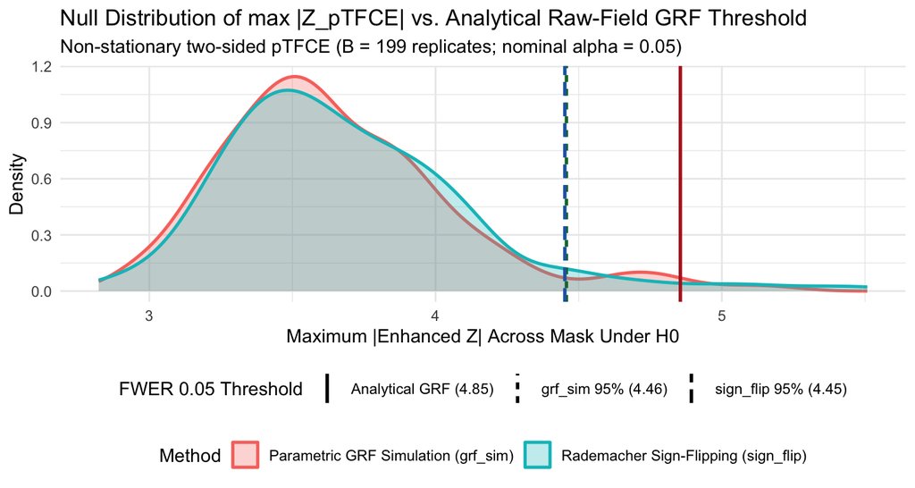

```r
set.seed(42)
cal_grf <- out_ns # analytical GRF from non-stationary demo above
cal_sim <- ptfce(z_ns, mask_ns, residual = res4d_ns, dof = nt_ns - 1,
                 sided = "two.sided", nonstationary = TRUE,
                 fwe_method = "grf_sim", n_perm = 199L, verbose = FALSE)
cal_sf  <- ptfce(z_ns, mask_ns, residual = res4d_ns, dof = nt_ns - 1,
                 sided = "two.sided", nonstationary = TRUE,
                 fwe_method = "sign_flip", n_perm = 199L, verbose = FALSE)

df_null <- rbind(
  data.frame(max_Z = cal_sim$null_max_Z, Method = "Parametric GRF Simulation (grf_sim)"),
  data.frame(max_Z = cal_sf$null_max_Z,  Method = "Rademacher Sign-Flipping (sign_flip)")
)
df_thr <- data.frame(
  Threshold = c(cal_grf$fwer0.05.Z, cal_sim$fwer0.05.Z, cal_sf$fwer0.05.Z),
  Label = c(
    sprintf("Analytical GRF (%.2f)", cal_grf$fwer0.05.Z),
    sprintf("grf_sim 95%% (%.2f)", cal_sim$fwer0.05.Z),
    sprintf("sign_flip 95%% (%.2f)", cal_sf$fwer0.05.Z)
  )
)

ggplot(df_null, aes(x = max_Z, fill = Method, color = Method)) +
  geom_density(alpha = 0.28, linewidth = 0.9) +
  geom_vline(data = df_thr, aes(xintercept = Threshold, linetype = Label),
             color = c("#b22222", "#1b7837", "#2166ac"), linewidth = 0.95) +
  labs(
    title = "Null Distribution of max |Z_pTFCE| vs. Analytical Raw-Field GRF Threshold",
    subtitle = "Non-stationary two-sided pTFCE (B = 199 replicates; nominal alpha = 0.05)",
    x = "Maximum |Enhanced Z| Across Mask Under H0",
    y = "Density",
    linetype = "FWER 0.05 Threshold"
  ) +
  theme_minimal(base_size = 11) +
  theme(legend.position = "bottom", legend.box = "vertical")
```

### 7.3 Monte Carlo Evaluation Across Realistic Group-fMRI Scenarios

We evaluated all FWER calibration modes across three 3D group-fMRI benchmarks (`36 x 26 x 18` search volume spanning three anatomical smoothness zones: rough subcortex `FWHM = 3.0`, moderate lateral cortex `FWHM = 4.8`, and smooth medial DMN `FWHM = 7.2` voxels; nominal two-sided $\alpha = 0.05$, $B = 199$ replicates per study):

| Scenario & Method | Mean `fwer0.05.Z` | Whole-Brain FWER | Subcortex Power (TPR) | Lat. Cortex Power (TPR) | Medial DMN Power (TPR) | Null Smooth-DMN FP |
| --- | --- | --- | --- | --- | --- | --- |
| **Gaussian Non-Stationary ($N = 25$, $R = 200$ null / $150$ signal)** |  |  |  |  |  |  |
| Unenhanced Raw $Z$ (`grf`) | `4.453` | — | 24.0% (3.7%) | 16.7% (1.3%) | 14.0% (1.2%) | 0.0% |
| Stationary pTFCE + `grf` | `4.452` | `0.010` | 12.7% (1.7%) | 12.7% (2.0%) | 22.7% (6.1%) | 0.0% |
| Stationary pTFCE + `grf_sim` | `4.094` | `0.065` | 22.7% (3.9%) | 24.0% (4.2%) | 33.3% (9.7%) | 2.7% |
| Non-Stationary pTFCE + `grf` (`v0.4.0`) | `4.502` | `0.015` | 18.0% (3.5%) | 8.0% (1.6%) | 10.0% (1.7%) | 0.0% |
| **Non-Stationary pTFCE + `grf_sim` (`v0.4.1`)** | **`4.135`** | **`0.045`** | **32.0% (7.3%)** | **24.7% (3.4%)** | **18.0% (3.4%)** | **0.0%** |
| **Non-Stationary pTFCE + `sign_flip` (`residual`, `v0.4.1`)** | **`4.141`** | **`0.050`** | **32.7% (7.3%)** | **24.7% (3.3%)** | **18.0% (3.3%)** | **0.0%** |
| **Non-Stationary pTFCE + `sign_flip` (`copes`, `v0.4.1`)** | **`4.142`** | **`0.045`** | **32.7% (7.4%)** | **22.7% (3.4%)** | **16.7% (3.5%)** | **0.0%** |
| **Heavy-Tailed / Outlier Non-Gaussian Null ($t_{3.5}$ + subject scale shocks, $N = 20$, $R = 200$)** |  |  |  |  |  |  |
| Non-Stationary pTFCE + `grf` | `4.522` | `0.005` | — | — | — | — |
| Non-Stationary pTFCE + `grf_sim` | `4.142` | `0.040` | — | — | — | — |
| Non-Stationary pTFCE + `sign_flip` (`residual`) | `3.946` | `0.065` | — | — | — | — |

## 8 Algorithmic Architecture (`Rcpp`) & Benchmarks

Upstream `pTFCE` executed `Nh = 100` full-volume 3D connected-component labeling sweeps (`mmand::components`) plus string-based frequency tables (`base::table(ccc)`) and allocated two 4D arrays (`dim(img) x Nh`).

In `src/ptfce_core.cpp`:

- **`ptfce_tail_cpp()`:** Collects only in-mask voxels with $Z > Z_{\text{estThr}}$ (~5–15% of total bounding-box voxels), sorts them once in descending order of intensity, and sweeps thresholds from high to low using a Disjoint-Set Union (Union-Find) structure with path compression and union-by-size. Voxel insertions and neighbor unions occur **at most once per supra-threshold voxel across the entire run**, making connected-component cost nearly independent of threshold density.
- **`smoothest_cpp()`:** Performs three sequential, cache-contiguous passes over 4D `res4d` volumes without duplicating the 4D array in memory.
- **`NullPtfceEngine` (`calibrate_fwer_grf_cpp` / `calibrate_fwer_signflip_cpp`):** Precomputes posterior normalization denominators once and populates a lazy 2D `(threshold x log_cluster_mass)` lookup table on demand, eliminating 100% of numerical Gauss–Kronrod quadrature inside the permutation/simulation loop and evaluating `qnorm` only once per replicate at the global maximum accumulator.

```r
r4d_path <- system.file("extdata", "test03A_res4d.nii.gz", package = "pTFCE")
m3a_path <- system.file("extdata", "test03A_mask.nii.gz", package = "pTFCE")
r4d <- readNifti(r4d_path)
m3a <- readNifti(m3a_path)

t_sm3d  <- system.time(sm3 <- smoothest(z_nii, m_nii, verbose = FALSE))["elapsed"]
t_sm4d  <- system.time(sm4 <- smoothest(r4d, m3a, dof = 22, nonstationary = TRUE, verbose = FALSE))["elapsed"]
t_1s    <- system.time(ptfce(z_nii, m_nii, Rd = Rd, V = V, resels = sm3$resels,
                             Nh = 100, legacy = TRUE, verbose = FALSE))["elapsed"]
t_2s    <- system.time(ptfce(z_nii, m_nii, Rd = Rd, V = V, resels = sm3$resels,
                             sided = "two.sided", dh = 0.05, verbose = FALSE))["elapsed"]
t_2s_ns <- system.time(ptfce(z_nii, m3a, local_smoothness = sm4,
                             sided = "two.sided", dh = 0.05, nonstationary = TRUE, verbose = FALSE))["elapsed"]
set.seed(1)
t_sf200 <- system.time(ptfce(z_nii, m3a, residual = r4d, dof = 22, local_smoothness = sm4,
                             sided = "two.sided", nonstationary = TRUE,
                             fwe_method = "sign_flip", n_perm = 200L, verbose = FALSE))["elapsed"]

bench_df <- data.frame(
  Operation = c(
    "3D smoothest() (301,461 mask voxels)",
    "4D smoothest(..., nonstationary = TRUE) (301,461 mask voxels x 25 volumes)",
    "1-sided ptfce() (legacy Nh = 100)",
    "Bi-sided ptfce() (sided = 'two.sided', dh = 0.05, stationary)",
    "Bi-sided ptfce() (sided = 'two.sided', dh = 0.05, nonstationary = TRUE, fwe_method = 'grf')",
    "Bi-sided ptfce() + Rademacher sign_flip FWER calibration (301,461 voxels, B = 200)"
  ),
  `Elapsed_Seconds` = c(t_sm3d, t_sm4d, t_1s, t_2s, t_2s_ns, t_sf200)
)
knitr::kable(bench_df, digits = 4, caption = "Wall-clock execution times on whole-brain test volumes.")
```

Wall-clock execution times on whole-brain test volumes.

| Operation | Elapsed_Seconds |
| --- | --- |
| 3D smoothest() (301,461 mask voxels) | 0.004 |
| 4D smoothest(…, nonstationary = TRUE) (301,461 mask voxels x 25 volumes) | 0.188 |
| 1-sided ptfce() (legacy Nh = 100) | 0.099 |
| Bi-sided ptfce() (sided = ‘two.sided’, dh = 0.05, stationary) | 0.325 |
| Bi-sided ptfce() (sided = ‘two.sided’, dh = 0.05, nonstationary = TRUE, fwe_method = ‘grf’) | 0.427 |
| Bi-sided ptfce() + Rademacher sign_flip FWER calibration (301,461 voxels, B = 200) | 2.969 |

## 9 Usage & Migration Notes

### 9.1 Recommended Bi-Sided fMRI Workflows

```r
library(pTFCE)

# 1. Recommended group-fMRI workflow: non-stationary bi-sided pTFCE + sign-flipping FWER
res <- ptfce(
  img = "zstat1.nii.gz",
  mask = "mask.nii.gz",
  residual = "res4d.nii.gz",   # or supply 4D subject contrasts via `copes = "copes4d.nii.gz"`
  dof = 42,
  sided = "two.sided",
  nonstationary = TRUE,
  fwe_method = "sign_flip",    # "grf" (default), "sign_flip", or "grf_sim"
  n_perm = 500L,
  connectivity = 6L,           # 6 (NN=1), 18 (NN=2), or 26 (NN=3)
  fwe_p = c(0.05, 0.01)
)

# 2. When only a 3D Z-map (plus optional RPV/local_smoothness) is available:
res_3d <- ptfce(
  img = "zstat1.nii.gz",
  mask = "mask.nii.gz",
  local_smoothness = "RPV.nii", # optional; omit for stationary smoothness
  sided = "two.sided",
  fwe_method = "grf_sim",
  n_perm = 500L
)

# 3. Reusing precomputed 4D local smoothness across multiple contrasts:
sm_ns <- smoothest("res4d.nii.gz", mask = "mask.nii.gz", dof = 42, nonstationary = TRUE)
res_cope1 <- ptfce("zstat1.nii.gz", mask = "mask.nii.gz", residual = "res4d.nii.gz", dof = 42,
                   local_smoothness = sm_ns, sided = "two.sided", fwe_method = "sign_flip")

# If starting from a t-statistic map instead of a Z-map:
z_img <- t2z("spmT_0001.nii.gz", dof = 42)
```

### 9.2 Known Statistical Properties & Remaining Future Directions

1. **Uncorrected voxelwise `res$p` vs. calibrated FWER thresholds:** While `fwe_method = "sign_flip"` and `fwe_method = "grf_sim"` calibrate exact non-conservative FWER thresholds (`res$fwer0.05.Z`, `res$fwe.Z`, and empirical FWER $p$-values via `(1 + sum(res$null_max_Z >= abs(z))) / (length(res$null_max_Z) + 1)`), the **uncorrected** voxelwise `res$p` map remains mildly conservative in the moderate range ($p \in [10^{-3}, 0.05]$) due to $H \ge Z_{\text{estThr}}$ truncation; thus naive Benjamini–Hochberg FDR on `res$p` remains conservative.
2. **Future enhancements:**
   - **Full Worsley (1996) 0D–3D resel vector ($R_0, R_1, R_2, R_3$):** Accurate boundary/surface Euler characteristic FWER terms for analytical small-volume correction (SVC) and thin cortical ribbon ROIs when `fwe_method = "grf"` is used.